# Open Class Python

Python ITB  
Makers Institute

13 February 2018

# About Us

Since 12 January 2016  
First open class: September 2016

[figure not shown]

# About Me

## Aris Budi Wibowo

about.me/arisbw | [@arisbw](http://twitter.com/arisbw)

# Outline

- Introduction to Python
- Let's use Pandas!
- Introduction to Machine Learning
- What the hell is KNN?

You can also view this repository from: https://github.com/arisbw/open-class-makers

# Introduction to Python

Say hello to dat snake. 🐍

```python
print("Hello Python!")
```

```
Hello Python!
```

## Object types in Python

[figure not shown]

### Number

If you forgot what the simple math looks like...

```python
1 + 1
```

```
2
```

```python
8 - 1
```

```
7
```

```python
10 * 2
```

```
20
```

```python
35 / 5
```

```
7.0
```

```python
5 // 3
```

```
1
```

```python
5.0 // 3.0
```

```
1.0
```

```python
2**4
```

```
16
```

### String

```python
s = "ayam"
len(s)
```

```
4
```

```python
s[0]
```

```
'a'
```

Or, we can do this!

```python
s[-1]
```

```
'm'
```

```python
s[-2]
```

```
'a'
```

We can also slice that string

```python
s[0:3]
```

```
'aya'
```

```python
s[1:]
```

```
'yam'
```

```python
s[:5]
```

```
'ayam'
```

```python
s[:-1]
```

```
'aya'
```

Or add with another string

```python
s + ' ' +'euy'
```

```
'ayam euy'
```

```python
s*4
```

```
'ayamayamayamayam'
```

Find and replace substring

```python
s.find('yam')
```

[output not shown]

```python
s.replace('ayam', 'bebek')
```

```
'bebek'
```

```python
line = 'aaa,bbb,ccccc,dd'
```

```python
line.split(',')
```

```
['aaa', 'bbb', 'ccccc', 'dd']
```

```python
s
```

```
'ayam'
```

```python
s.upper()
```

```
'AYAM'
```

```python
s.isalpha()
```

```
True
```

### List

```python
L = [123, 'spam', 1.23]
```

```python
L[0]
```

```
123
```

```python
L[:-1]
```

```
[123, 'spam']
```

```python
L + [4, 5, 6]
```

```
[123, 'spam', 1.23, 4, 5, 6]
```

```python
L
```

```
[123, 'spam', 1.23]
```

```python
L.append('hehe')
```

```python
L
```

```
[123, 'spam', 1.23, 'hehe']
```

```python
L.pop(1)
```

```
'spam'
```

```python
L
```

```
[123, 1.23, 'hehe']
```

### Dictionaries

```python
D = {'food': 'Spam', 'quantity': 4, 'color': 'pink'}
```

```python
D['food']
```

```
'Spam'
```

```python
D['quantity']
```

```
4
```

```python
D = {}
D['name'] = 'Bob'# Create keys by assignment
D['job']  = 'dev'
D['age']  = 40
```

```python
D
```

```
{'age': 40, 'job': 'dev', 'name': 'Bob'}
```

### What if...

```python
a = 90

if a > 50:
    print("Lebih dari 50")
else:
    print("Kurang dari 50")
```

```
Lebih dari 50
```

```python
a = 3
"seeep" if a > 2 else 2
```

```
'seeep'
```

Now, what ifs...

```python
a = 400

if a < 100:
    print("Kurang dari 100")
elif a >= 100 and a <= 500:
    print("Antara 100 dan 500")
else:
    print("Lebih dari 500")
```

```
Antara 100 dan 500
```

... say that again?

```python
a = 5

for i in range(a):
    if a > 10:
        print("Lebih dari 10")
    else:
        print("Kurang dari 10")
```

```
Kurang dari 10
Kurang dari 10
Kurang dari 10
Kurang dari 10
Kurang dari 10
```

```python
a = ['ayam', 'kucing', 'anjing']

for binatang in a:
    print(binatang)
```

```
ayam
kucing
anjing
```

or

```python
a = 0

while a < 5:
    print("Gampang euy")
    a += 1
```

```
Gampang euy
Gampang euy
Gampang euy
Gampang euy
Gampang euy
```

Functions!

```python
def tambah(a=0,b=0):
    c = a+b
    return c

tambah(2,3)
```

```
5
```

# Pandas!

[figure not shown]

Initialize libraries that we will use later.

```python
import pandas as pd
import matplotlib.pyplot as plt

%matplotlib inline
```

First, let's download the data we need.

```python
!curl https://raw.githubusercontent.com/fivethirtyeight/data/master/bob-ross/elements-by-episode.csv -O elements-by-episode.csv
```

```
  % Total    % Received % Xferd  Average Speed   Time    Time     Time  Current
                                 Dload  Upload   Total   Spent    Left  Speed

  0     0    0     0    0     0      0      0 --:--:-- --:--:-- --:--:--     0
100 66316  100 66316    0     0   121k      0 --:--:-- --:--:-- --:--:--  121k

  0     0    0     0    0     0      0      0 --:--:-- --:--:-- --:--:--     0
  0     0    0     0    0     0      0      0 --:--:-- --:--:-- --:--:--     0
```

Or you can use wget if you use linux.

```python
df  =  pd.read_csv("elements-by-episode.csv")
```

Let's peek the data.

```python
df.head()
```

|  | EPISODE | TITLE | APPLE_FRAME | AURORA_BOREALIS | BARN | BEACH | BOAT | BRIDGE | BUILDING | BUSHES | ... | TOMB_FRAME | TREE | TREES | TRIPLE_FRAME | WATERFALL | WAVES | WINDMILL | WINDOW_FRAME | WINTER | WOOD_FRAMED |
| --- | --- | --- | --- | --- | --- | --- | --- | --- | --- | --- | --- | --- | --- | --- | --- | --- | --- | --- | --- | --- | --- |
| 0 | S01E01 | "A WALK IN THE WOODS" | 0 | 0 | 0 | 0 | 0 | 0 | 0 | 1 | ... | 0 | 1 | 1 | 0 | 0 | 0 | 0 | 0 | 0 | 0 |
| 1 | S01E02 | "MT. MCKINLEY" | 0 | 0 | 0 | 0 | 0 | 0 | 0 | 0 | ... | 0 | 1 | 1 | 0 | 0 | 0 | 0 | 0 | 1 | 0 |
| 2 | S01E03 | "EBONY SUNSET" | 0 | 0 | 0 | 0 | 0 | 0 | 0 | 0 | ... | 0 | 1 | 1 | 0 | 0 | 0 | 0 | 0 | 1 | 0 |
| 3 | S01E04 | "WINTER MIST" | 0 | 0 | 0 | 0 | 0 | 0 | 0 | 1 | ... | 0 | 1 | 1 | 0 | 0 | 0 | 0 | 0 | 0 | 0 |
| 4 | S01E05 | "QUIET STREAM" | 0 | 0 | 0 | 0 | 0 | 0 | 0 | 0 | ... | 0 | 1 | 1 | 0 | 0 | 0 | 0 | 0 | 0 | 0 |

5 rows × 69 columns

```python
df.columns
```

```
Index(['EPISODE', 'TITLE', 'APPLE_FRAME', 'AURORA_BOREALIS', 'BARN', 'BEACH',
       'BOAT', 'BRIDGE', 'BUILDING', 'BUSHES', 'CABIN', 'CACTUS',
       'CIRCLE_FRAME', 'CIRRUS', 'CLIFF', 'CLOUDS', 'CONIFER', 'CUMULUS',
       'DECIDUOUS', 'DIANE_ANDRE', 'DOCK', 'DOUBLE_OVAL_FRAME', 'FARM',
       'FENCE', 'FIRE', 'FLORIDA_FRAME', 'FLOWERS', 'FOG', 'FRAMED', 'GRASS',
       'GUEST', 'HALF_CIRCLE_FRAME', 'HALF_OVAL_FRAME', 'HILLS', 'LAKE',
       'LAKES', 'LIGHTHOUSE', 'MILL', 'MOON', 'MOUNTAIN', 'MOUNTAINS', 'NIGHT',
       'OCEAN', 'OVAL_FRAME', 'PALM_TREES', 'PATH', 'PERSON', 'PORTRAIT',
       'RECTANGLE_3D_FRAME', 'RECTANGULAR_FRAME', 'RIVER', 'ROCKS',
       'SEASHELL_FRAME', 'SNOW', 'SNOWY_MOUNTAIN', 'SPLIT_FRAME', 'STEVE_ROSS',
       'STRUCTURE', 'SUN', 'TOMB_FRAME', 'TREE', 'TREES', 'TRIPLE_FRAME',
       'WATERFALL', 'WAVES', 'WINDMILL', 'WINDOW_FRAME', 'WINTER',
       'WOOD_FRAMED'],
      dtype='object')
```

```python
df.shape
```

```
(403, 69)
```

Summary of the data:

```python
df.describe()
```

|  | APPLE_FRAME | AURORA_BOREALIS | BARN | BEACH | BOAT | BRIDGE | BUILDING | BUSHES | CABIN | CACTUS | ... | TOMB_FRAME | TREE | TREES | TRIPLE_FRAME | WATERFALL | WAVES | WINDMILL | WINDOW_FRAME | WINTER | WOOD_FRAMED |
| --- | --- | --- | --- | --- | --- | --- | --- | --- | --- | --- | --- | --- | --- | --- | --- | --- | --- | --- | --- | --- | --- |
| count | 403.000000 | 403.000000 | 403.000000 | 403.000000 | 403.000000 | 403.000000 | 403.000000 | 403.000000 | 403.000000 | 403.000000 | ... | 403.000000 | 403.000000 | 403.000000 | 403.000000 | 403.000000 | 403.000000 | 403.000000 | 403.000000 | 403.000000 | 403.000000 |
| mean | 0.002481 | 0.004963 | 0.042184 | 0.066998 | 0.004963 | 0.017370 | 0.002481 | 0.297767 | 0.171216 | 0.009926 | ... | 0.002481 | 0.895782 | 0.836228 | 0.002481 | 0.096774 | 0.084367 | 0.002481 | 0.002481 | 0.171216 | 0.002481 |
| std | 0.049814 | 0.070359 | 0.201258 | 0.250328 | 0.070359 | 0.130807 | 0.049814 | 0.457845 | 0.377166 | 0.099255 | ... | 0.049814 | 0.305923 | 0.370528 | 0.049814 | 0.296018 | 0.278283 | 0.049814 | 0.049814 | 0.377166 | 0.049814 |
| min | 0.000000 | 0.000000 | 0.000000 | 0.000000 | 0.000000 | 0.000000 | 0.000000 | 0.000000 | 0.000000 | 0.000000 | ... | 0.000000 | 0.000000 | 0.000000 | 0.000000 | 0.000000 | 0.000000 | 0.000000 | 0.000000 | 0.000000 | 0.000000 |
| 25% | 0.000000 | 0.000000 | 0.000000 | 0.000000 | 0.000000 | 0.000000 | 0.000000 | 0.000000 | 0.000000 | 0.000000 | ... | 0.000000 | 1.000000 | 1.000000 | 0.000000 | 0.000000 | 0.000000 | 0.000000 | 0.000000 | 0.000000 | 0.000000 |
| 50% | 0.000000 | 0.000000 | 0.000000 | 0.000000 | 0.000000 | 0.000000 | 0.000000 | 0.000000 | 0.000000 | 0.000000 | ... | 0.000000 | 1.000000 | 1.000000 | 0.000000 | 0.000000 | 0.000000 | 0.000000 | 0.000000 | 0.000000 | 0.000000 |
| 75% | 0.000000 | 0.000000 | 0.000000 | 0.000000 | 0.000000 | 0.000000 | 0.000000 | 1.000000 | 0.000000 | 0.000000 | ... | 0.000000 | 1.000000 | 1.000000 | 0.000000 | 0.000000 | 0.000000 | 0.000000 | 0.000000 | 0.000000 | 0.000000 |
| max | 1.000000 | 1.000000 | 1.000000 | 1.000000 | 1.000000 | 1.000000 | 1.000000 | 1.000000 | 1.000000 | 1.000000 | ... | 1.000000 | 1.000000 | 1.000000 | 1.000000 | 1.000000 | 1.000000 | 1.000000 | 1.000000 | 1.000000 | 1.000000 |

8 rows × 67 columns

Transpose the data

```python
df.T.head()
```

|  | 0 | 1 | 2 | 3 | 4 | 5 | 6 | 7 | 8 | 9 | ... | 393 | 394 | 395 | 396 | 397 | 398 | 399 | 400 | 401 | 402 |
| --- | --- | --- | --- | --- | --- | --- | --- | --- | --- | --- | --- | --- | --- | --- | --- | --- | --- | --- | --- | --- | --- |
| EPISODE | S01E01 | S01E02 | S01E03 | S01E04 | S01E05 | S01E06 | S01E07 | S01E08 | S01E09 | S01E10 | ... | S31E04 | S31E05 | S31E06 | S31E07 | S31E08 | S31E09 | S31E10 | S31E11 | S31E12 | S31E13 |
| TITLE | "A WALK IN THE WOODS" | "MT. MCKINLEY" | "EBONY SUNSET" | "WINTER MIST" | "QUIET STREAM" | "WINTER MOON" | "AUTUMN MOUNTAINS" | "PEACEFUL VALLEY" | "SEASCAPE" | "MOUNTAIN LAKE" | ... | "TRANQUILITY COVE" | "CABIN IN THE HOLLOW" | "VIEW FROM CLEAR CREEK" | "BRIDGE TO AUTUMN" | "TRAIL'S END" | "EVERGREEN VALLEY" | "BALMY BEACH" | "LAKE AT THE RIDGE" | "IN THE MIDST OF WINTER" | "WILDERNESS DAY" |
| APPLE_FRAME | 0 | 0 | 0 | 0 | 0 | 0 | 0 | 0 | 0 | 0 | ... | 0 | 0 | 0 | 0 | 0 | 0 | 0 | 0 | 0 | 0 |
| AURORA_BOREALIS | 0 | 0 | 0 | 0 | 0 | 0 | 0 | 0 | 0 | 0 | ... | 0 | 0 | 0 | 0 | 0 | 0 | 0 | 0 | 0 | 0 |
| BARN | 0 | 0 | 0 | 0 | 0 | 0 | 0 | 0 | 0 | 0 | ... | 0 | 0 | 0 | 0 | 0 | 0 | 0 | 0 | 1 | 0 |

5 rows × 403 columns

Sort the data

```python
df.sort_values(by='TREES',ascending=False).head()
```

|  | EPISODE | TITLE | APPLE_FRAME | AURORA_BOREALIS | BARN | BEACH | BOAT | BRIDGE | BUILDING | BUSHES | ... | TOMB_FRAME | TREE | TREES | TRIPLE_FRAME | WATERFALL | WAVES | WINDMILL | WINDOW_FRAME | WINTER | WOOD_FRAMED |
| --- | --- | --- | --- | --- | --- | --- | --- | --- | --- | --- | --- | --- | --- | --- | --- | --- | --- | --- | --- | --- | --- |
| 0 | S01E01 | "A WALK IN THE WOODS" | 0 | 0 | 0 | 0 | 0 | 0 | 0 | 1 | ... | 0 | 1 | 1 | 0 | 0 | 0 | 0 | 0 | 0 | 0 |
| 263 | S21E04 | "SERENITY" | 0 | 0 | 0 | 0 | 0 | 0 | 0 | 0 | ... | 0 | 1 | 1 | 0 | 1 | 0 | 0 | 0 | 0 | 0 |
| 261 | S21E02 | "TRANQUIL DAWN" | 0 | 0 | 0 | 0 | 0 | 0 | 0 | 0 | ... | 0 | 1 | 1 | 0 | 0 | 0 | 0 | 0 | 0 | 0 |
| 260 | S21E01 | "VALLEY VIEW" | 0 | 0 | 0 | 0 | 0 | 0 | 0 | 0 | ... | 0 | 1 | 1 | 0 | 0 | 0 | 0 | 0 | 0 | 0 |
| 259 | S20E13 | "DOUBLE TAKE" | 0 | 0 | 0 | 0 | 0 | 0 | 0 | 1 | ... | 0 | 1 | 1 | 0 | 0 | 0 | 0 | 0 | 1 | 0 |

5 rows × 69 columns

Select and Slice

```python
df.EPISODE[1:5]
```

```
1    S01E02
2    S01E03
3    S01E04
4    S01E05
Name: EPISODE, dtype: object
```

```python
df['EPISODE'][1:5]
```

```
1    S01E02
2    S01E03
3    S01E04
4    S01E05
Name: EPISODE, dtype: object
```

```python
df.loc[0:2]
```

|  | EPISODE | TITLE | APPLE_FRAME | AURORA_BOREALIS | BARN | BEACH | BOAT | BRIDGE | BUILDING | BUSHES | ... | TOMB_FRAME | TREE | TREES | TRIPLE_FRAME | WATERFALL | WAVES | WINDMILL | WINDOW_FRAME | WINTER | WOOD_FRAMED |
| --- | --- | --- | --- | --- | --- | --- | --- | --- | --- | --- | --- | --- | --- | --- | --- | --- | --- | --- | --- | --- | --- |
| 0 | S01E01 | "A WALK IN THE WOODS" | 0 | 0 | 0 | 0 | 0 | 0 | 0 | 1 | ... | 0 | 1 | 1 | 0 | 0 | 0 | 0 | 0 | 0 | 0 |
| 1 | S01E02 | "MT. MCKINLEY" | 0 | 0 | 0 | 0 | 0 | 0 | 0 | 0 | ... | 0 | 1 | 1 | 0 | 0 | 0 | 0 | 0 | 1 | 0 |
| 2 | S01E03 | "EBONY SUNSET" | 0 | 0 | 0 | 0 | 0 | 0 | 0 | 0 | ... | 0 | 1 | 1 | 0 | 0 | 0 | 0 | 0 | 1 | 0 |

3 rows × 69 columns

```python
df.loc[100:106,['WATERFALL','TREE']]
```

|  | WATERFALL | TREE |
| --- | --- | --- |
| 100 | 0 | 0 |
| 101 | 0 | 1 |
| 102 | 0 | 1 |
| 103 | 0 | 1 |
| 104 | 0 | 1 |
| 105 | 0 | 0 |
| 106 | 0 | 1 |

```python
df[(df.BRIDGE>0) & (df.WINTER>0)]
```

|  | EPISODE | TITLE | APPLE_FRAME | AURORA_BOREALIS | BARN | BEACH | BOAT | BRIDGE | BUILDING | BUSHES | ... | TOMB_FRAME | TREE | TREES | TRIPLE_FRAME | WATERFALL | WAVES | WINDMILL | WINDOW_FRAME | WINTER | WOOD_FRAMED |
| --- | --- | --- | --- | --- | --- | --- | --- | --- | --- | --- | --- | --- | --- | --- | --- | --- | --- | --- | --- | --- | --- |
| 240 | S19E07 | "COVERED BRIDGE OVAL" | 0 | 0 | 0 | 0 | 0 | 1 | 0 | 0 | ... | 0 | 1 | 1 | 0 | 0 | 0 | 0 | 0 | 1 | 0 |

1 rows × 69 columns

[figure not shown]

```python
df1 = df.iloc[:,3:6]
```

```python
df1.head()
```

|  | AURORA_BOREALIS | BARN | BEACH |
| --- | --- | --- | --- |
| 0 | 0 | 0 | 0 |
| 1 | 0 | 0 | 0 |
| 2 | 0 | 0 | 0 |
| 3 | 0 | 0 | 0 |
| 4 | 0 | 0 | 0 |

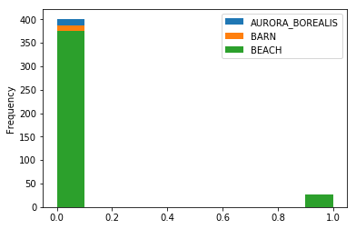

```python
df1.plot.hist()
```

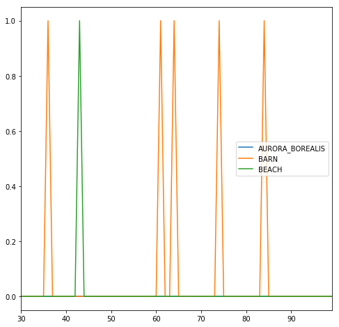

```python
df1.iloc[30:100,:].plot(figsize=(8, 8))
```

# a bit Intro to Machine Learning

## What is Machine Learning?

[figure not shown]

Machine Learning: *... a method of teaching computers to make and improve predictions or behaviors based on some data.*

Basically, there are 3`*` main task in machine learning:

- Supervised learning: your examples must be *labeled*
- Unsupervised learning: your examples are *not labeled*
- Reinforcement learning: based on *reward* and *punishment*

## Why Machine Learning?

[figure not shown]

I mean... *why now?*

[figure not shown]

So many algorithms that are really good right now:

- SVM
- Tree-based algorithms: Random forest, XGboost, catboost
- Deep learning
- etc.

[figure not shown]

# a bit of KNN

DISCLAIMER: This is the *oversimplified* version

A classification and regression method. In this case, we will explore in the classification problem.

[figure not shown]

```python
from sklearn import neighbors
import numpy as np
%matplotlib inline
import seaborn
```

Create dataset:

```python
training_data = pd.DataFrame()

training_data['test_1'] = [0.3051,0.4949,0.6974,0.3769,0.2231,0.341,0.4436,0.5897,0.6308,0.5]
training_data['test_2'] = [0.5846,0.2654,0.2615,0.4538,0.4615,0.8308,0.4962,0.3269,0.5346,0.6731]
training_data['outcome'] = ['win','win','win','win','win','loss','loss','loss','loss','loss']

training_data.head()
```

|  | test_1 | test_2 | outcome |
| --- | --- | --- | --- |
| 0 | 0.3051 | 0.5846 | win |
| 1 | 0.4949 | 0.2654 | win |
| 2 | 0.6974 | 0.2615 | win |
| 3 | 0.3769 | 0.4538 | win |
| 4 | 0.2231 | 0.4615 | win |

Plot the data

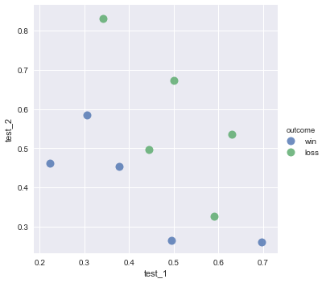

```python
seaborn.lmplot('test_1', 'test_2', data=training_data, fit_reg=False,hue="outcome", scatter_kws={"marker": "D","s": 100})
```

Convert data to np.arrays

```python
X = training_data.as_matrix(columns=['test_1', 'test_2'])
y = np.array(training_data['outcome'])
```

Training!

```python
clf = neighbors.KNeighborsClassifier(3, weights = 'uniform')
trained_model = clf.fit(X, y)
```

*drum rolls* 🥁

```python
trained_model.score(X, y)
```

```
0.80000000000000004
```

Check the model result to new data point

```python
x_test = np.array([[.4,.6]])
```

```python
trained_model.predict(x_test)
```

```
array(['loss'], dtype=object)
```

Check result

```python
trained_model.predict_proba(x_test)
```

```
array([[ 0.66666667,  0.33333333]])
```

## Best k?

[figure not shown]

Load libraries

```python
from sklearn.neighbors import KNeighborsClassifier
from sklearn import datasets
from sklearn.preprocessing import StandardScaler
from sklearn.pipeline import Pipeline, FeatureUnion
from sklearn.model_selection import GridSearchCV
```

Load Iris Flower Data

```python
iris = datasets.load_iris()
X = iris.data
y = iris.target
```

Standardize Data

```python
standardizer = StandardScaler()

X_std = standardizer.fit_transform(X)
```

Create knn model

```python
knn = KNeighborsClassifier(n_neighbors=5, metric='euclidean', n_jobs=-1).fit(X_std, y)
```

Create search space of possible value of k

```python
pipe = Pipeline([('standardizer', standardizer), ('knn', knn)])

search_space = [{'knn__n_neighbors': [1, 2, 3, 4, 5, 6, 7, 8, 9, 10]}]
```

Search!

```python
clf = GridSearchCV(pipe, search_space, cv=5, verbose=0).fit(X_std, y)
```

Show best k

```python
clf.best_estimator_.get_params()['knn__n_neighbors']
```

```
6
```

# References

- [Learn X in Y Minutes](https://learnxinyminutes.com/docs/python3/)
- [A Statistical Analysis of the Work of Bob Ross](https://fivethirtyeight.com/features/a-statistical-analysis-of-the-work-of-bob-ross/)
- [Learning Python](https://www.safaribooksonline.com/library/view/learning-python-3rd/9780596513986/)
- [10 Minutes to pandas](https://pandas.pydata.org/pandas-docs/stable/10min.html#plotting)
- [What's Driving the Machine Learning Explosion?](https://hbr.org/2017/07/whats-driving-the-machine-learning-explosion)
- [What is the difference between supervised learning and unsupervised learning?](https://stackoverflow.com/questions/1832076/what-is-the-difference-between-supervised-learning-and-unsupervised-learning)
- [Data Never Sleeps 5.0](https://www.domo.com/learn/data-never-sleeps-5)
- [K-Nearest Neighbors Classification](https://chrisalbon.com/machine_learning/nearest_neighbors/k-nearest_neighbors_classifer/)
- [What is the best way to explain the bias-variance trade-off in layman’s terms?](https://www.quora.com/What-is-the-best-way-to-explain-the-bias-variance-trade-off-in-layman%E2%80%99s-terms)

# Thank you! 🙇‍🙏

# Misc.

```python
%mkdir image\paintings
%cd image\paintings
```

```
D:\Google Drive\Python ITB\Kelas Makers\image\paintings
```

```python
#Credit to: Jeff Thompson (https://gist.github.com/jeffThompson/6d4c45f89dc907925775972e72d9cf00)

num_images=403

import urllib.request
from tqdm import *

for i in tqdm(range(1, num_images+1)):
    try:
        url = 'http://www.twoinchbrush.com/images/painting' + str(i) + '.png'
        filename = ('%03d' % (i,)) + '.png'
        urllib.request.urlretrieve(url, filename)
    except:
        print('- ERROR!')
```